# 3 Covarianzas con pocos datos: el cono SPD y su estimación

**NotaEn este capítulo**

**Pregunta.** ¿Cuánto me fío de una covarianza estimada?

**Objetivos.** Cuantificar cuánto de la distancia entre dos covarianzas estimadas es ruido de estimación, cómo depende de la métrica y de $T/n$, y con qué hipótesis. Ver qué le hacen a las distancias la autocorrelación de las muestras, la contracción y la pérdida de rango.

**Prerrequisitos.** Capítulo 2. Las distancias y la invariancia afín se usan aquí a nivel de enunciado; se demuestran en el capítulo 4.

**Código.** Los experimentos usan datos sintéticos con semilla fija y funciones de `NeuroRiemann.jl` (`distance`, `isspd`, `logm`). Los generadores (muestras gaussianas, procesos AR(2)) son provisionales: pasarán al paquete con la cohorte (apéndice D).

## 3.1 La pregunta

Una covarianza calculada con $T$ muestras no es la covarianza del proceso: es una **matriz aleatoria**. Si se comparan dos, parte de su distancia es ruido de estimación y no diferencia real. ¿Cuánto? ¿Depende de la métrica? ¿Qué pasa cuando hay pocas muestras por canal, cuando las muestras están autocorrelacionadas o cuando la matriz pierde rango? Sin esa referencia, un valor de distancia no se puede interpretar, y los contrastes del capítulo 6 tampoco.

Solo hace falta un resultado de álgebra, que se usa más abajo:

**Proposición 3.1 (La congruencia conserva el cono)** Si $P\in\SPD_n$ y $W\in\R^{m\times n}$ tiene rango $m$ (con $m\le n$), entonces $WPW^\top\in\SPD_m$. Demostrado

*Demostración*. $WPW^\top$ es simétrica. Para $x\in\R^m$ no nulo, $y=W^\top x\neq0$ porque $W^\top$ es inyectiva, y $x^\top WPW^\top x=y^\top Py>0$.

## 3.2 Una covarianza estimada es una matriz aleatoria

Sean $x_1,\dots,x_T\in\R^n$ independientes con distribución $N(0,\Sigma)$, $\Sigma\in\SPD_n$, y
$$P=\frac1T\sum_{t=1}^Tx_tx_t^\top .
\tag{3.1}$$
Es semidefinida positiva por la misma razón que el espectro cruzado (teorema 2.1) y definida positiva si y solo si los $x_t$ generan $\R^n$, lo que exige $T\ge n$. Las conclusiones de este capítulo valen **bajo las hipótesis de la Tabla 3.1**; cada experimento muestra qué ocurre al relajar una.

Tabla 3.1: Hipótesis de los resultados de este capítulo.

| Hipótesis | Si no se cumple |
| --- | --- |
| Media conocida y nula, normalización $1/T$ | Con la media estimada, el divisor natural es $T-1$ y los resultados se desplazan en $O(1/T)$ |
| Gaussianidad | La varianza de $P_{ij}$ cambia con los cumulantes de cuarto orden |
| Muestras independientes | Autocorrelación: el número efectivo de muestras es menor que $T$ (Experimento 2) |
| Régimen $T\gg n$ y primer orden del logaritmo | Con $T/n$ pequeño el ruido de $\dAI$ crece más que el pronóstico (Experimento 1) |
| Métrica sin factores constantes | $d_{FR}=d_{AI}/\sqrt2$ si se usa la métrica de Fisher–Rao |

### 3.2.1 El suelo de ruido

**Teorema 3.1 (La distancia afín-invariante al valor verdadero no depende de $\Sigma$)** En las condiciones anteriores, sea $W=\Sigma^{-1/2}P\Sigma^{-1/2}$. Entonces:

1. $\dAI(P,\Sigma)=\|\Logm W\|_F$, y la distribución de $W$ no depende de $\Sigma$: es la de $\tfrac1T\sum_tz_tz_t^\top$ con $z_t\sim N(0,I)$.
2. Si $P'$ es otra estimación independiente con los mismos $\Sigma$ y $T$, $\dAI(P,P')=\dAI(W,W')$.
3. $\mathbb E\,\|W-I\|_F^2=\dfrac{n(n+1)}{T}$.

Demostrado

*Demostración*.

1. La congruencia por $\Sigma^{-1/2}$ no cambia $\dAI$ (Proposición 4.6), así que $\dAI(P,\Sigma)=\dAI(W,I)=\|\Logm W\|_F$. Además $z_t=\Sigma^{-1/2}x_t\sim N(0,I)$ y $W=\tfrac1T\sum_tz_tz_t^\top$. (2) Es la misma invariancia aplicada a $P$ y $P'$.
2. $W-I=\tfrac1T\sum_t(z_tz_t^\top-I)$. Fuera de la diagonal, $W_{ij}=\tfrac1T\sum_tz_{t,i}z_{t,j}$ tiene media $0$ y varianza $1/T$ (porque $\mathbb E[z_i^2z_j^2]=1$ si $i\neq j$). En la diagonal, $W_{ii}-1=\tfrac1T\sum_t(z_{t,i}^2-1)$ tiene media $0$ y varianza $2/T$ (la de un $\chi^2_1$ es $2$). Sumando las $n(n-1)$ entradas de fuera de la diagonal y las $n$ de la diagonal, $\mathbb E\|W-I\|_F^2=\tfrac{n(n-1)+2n}{T}=\tfrac{n(n+1)}{T}$.

Como $\Logm W\approx W-I$ cuando $W$ está cerca de $I$, el teorema da la **estimación de primer orden**
$$\mathbb E\,\dAI(P,\Sigma)^2\approx\frac{n(n+1)}{T},\qquad \mathbb E\,\dAI(P,P')^2\approx\frac{2n(n+1)}{T}.
\tag{3.2}$$
La segunda cantidad es el **suelo de ruido**: la distancia que se observaría entre dos registros con exactamente la misma covarianza verdadera. Es una aproximación, válida para $T\gg n$; el Experimento 1 mide cuánto falla. Hipótesis sintética

La euclídea no tiene esa propiedad:

**Teorema 3.2 (La distancia euclídea sí depende de $\Sigma$)** En las mismas condiciones, $\mathbb E\,\|P-\Sigma\|_F^2=\dfrac{(\tr\Sigma)^2+\tr(\Sigma^2)}{T}$. Demostrado

*Demostración*. Por el teorema de Isserlis para gaussianas, $\mathbb E[x_ix_jx_ix_j]=\Sigma_{ii}\Sigma_{jj}+2\Sigma_{ij}^2$, de modo que $\operatorname{Var}(x_ix_j)=\Sigma_{ii}\Sigma_{jj}+\Sigma_{ij}^2$ y $\operatorname{Var}(P_{ij})=\tfrac1T\big(\Sigma_{ii}\Sigma_{jj}+\Sigma_{ij}^2\big)$. Sumando sobre todas las entradas, $\sum_{ij}\Sigma_{ii}\Sigma_{jj}=(\tr\Sigma)^2$ y $\sum_{ij}\Sigma_{ij}^2=\tr(\Sigma^2)$.

El error euclídeo crece con la **escala** de $\Sigma$ (con las unidades de la señal) y con su estructura; el afín-invariante, no. Es la invariancia afín «en acción».

## 3.3 Experimento 1: el suelo de ruido frente a $T/n$

Con $n=8$ canales, comparamos dos covarianzas verdaderas: $\Sigma_1=I$ y $\Sigma_2$, de número de condición $100$ y escala $50$. Para cada $T$ se generan $R=400$ réplicas, se calcula $P$ y se estima $\mathbb E\,d^2$ con su error estándar.

**Código**

```julia
using NeuroRiemann, LinearAlgebra, StableRNGs, Statistics, CairoMakie

"SPD de tamaño n con autovalores logarítmicamente espaciados entre 1 y κ, por una escala."
function spd_kappa(rng, n, κ; escala = 1.0)
    Q = Matrix(qr(randn(rng, n, n)).Q)
    return escala * symmetrize(Q * Diagonal(exp.(range(0, log(κ); length = n))) * Q')
end

"Covarianza muestral (@eq-covarianza-muestral) de T muestras N(0, Σ), con media conocida."
muestra(rng, Σ, T) = (X = cholesky(Σ).L * randn(rng, size(Σ, 1), T); Symmetric(X * X' / T))

dAI(A, B) = distance(AffineInvariant(), A, B)
ee(v) = std(v) / sqrt(length(v))                 # error estándar de una media Monte Carlo
nothing
```

**Código**

```julia
function experimento_suelo(; n = 8, R = 400, Ts = (16, 32, 64, 128, 512))
    rng = StableRNG(20261109)
    Σ1 = Matrix(1.0I, n, n); Σ2 = spd_kappa(rng, n, 100; escala = 50.0)
    filas = map(Ts) do T
        d1 = [dAI(muestra(rng, Σ1, T), Σ1)^2 for _ in 1:R]
        d2 = [dAI(muestra(rng, Σ2, T), Σ2)^2 for _ in 1:R]
        dd = [dAI(muestra(rng, Σ1, T), muestra(rng, Σ1, T))^2 for _ in 1:R]
        e1 = [norm(muestra(rng, Σ1, T) - Σ1)^2 for _ in 1:R]
        e2 = [norm(muestra(rng, Σ2, T) - Σ2)^2 for _ in 1:R]
        λ = [eigvals(muestra(rng, Σ1, T)) for _ in 1:R]
        (; T, c = n / T, pred = n * (n + 1) / T, d1 = mean(d1), ee1 = ee(d1), d2 = mean(d2), ee2 = ee(d2), dd = mean(dd),
           e1 = mean(e1), ex1 = (tr(Σ1)^2 + tr(Σ1^2)) / T, e2 = mean(e2), ex2 = (tr(Σ2)^2 + tr(Σ2^2)) / T,
           lmin = mean(first.(λ)), lmax = mean(last.(λ)))
    end
    return filas, n
end
filas, n_exp = experimento_suelo()
f3(x) = round(x; sigdigits = 3)
println("| \$T\$ | \$T/n\$ | \$n(n+1)/T\$ | \$\\mathbb E\\,d_{AI}^2(P,\\Sigma_1)\$ | \$\\mathbb E\\,d_{AI}^2(P,\\Sigma_2)\$ | \$\\mathbb E\\,d_{AI}^2(P,P')\$ | \$2n(n+1)/T\$ |\n|---|---|---|---|---|---|---|")
for f in filas
    println("| ", f.T, " | ", f3(1 / f.c), " | ", f3(f.pred), " | ", f3(f.d1), " ± ", f3(f.ee1), " | ", f3(f.d2), " ± ", f3(f.ee2), " | ", f3(f.dd), " | ", f3(2 * f.pred), " |")
end
println("\n: Distancia afín-invariante al cuadrado entre covarianzas estimadas (\$n=8\$, 400 réplicas; error estándar tras ±). {#tbl-suelo-ai}\n")
println("| \$T\$ | \$\\mathbb E\\|P-\\Sigma_1\\|^2\$ (MC) | exacto (@thm-euclidea-suelo) | \$\\mathbb E\\|P-\\Sigma_2\\|^2\$ (MC) | exacto |\n|---|---|---|---|---|")
for f in filas
    println("| ", f.T, " | ", f3(f.e1), " | ", f3(f.ex1), " | ", f3(f.e2), " | ", f3(f.ex2), " |")
end
println("\n: Distancia euclídea al cuadrado a la covarianza verdadera, con \$\\Sigma_2\$ de escala 50. {#tbl-suelo-euclidea}\n")
println("| \$T/n\$ | \$\\lambda_{\\min}\$ de \$P\$ | \$(1-\\sqrt c)^2\$ | \$\\lambda_{\\max}\$ de \$P\$ | \$(1+\\sqrt c)^2\$ |\n|---|---|---|---|---|")
for f in filas
    println("| ", f3(1 / f.c), " | ", f3(f.lmin), " | ", f3((1 - sqrt(f.c))^2), " | ", f3(f.lmax), " | ", f3((1 + sqrt(f.c))^2), " |")
end
println("\n: Autovalores extremos de \$P\$ con \$\\Sigma_1=I\$ frente a los bordes de Marchenko–Pastur, con \$c=n/T\$. {#tbl-mp}")
nothing
```

Tabla 3.2: Distancia afín-invariante al cuadrado entre covarianzas estimadas ($n=8$, 400 réplicas; error estándar tras ±).

| $T$ | $T/n$ | $n(n+1)/T$ | $\mathbb E\,d_{AI}^2(P,\Sigma_1)$ | $\mathbb E\,d_{AI}^2(P,\Sigma_2)$ | $\mathbb E\,d_{AI}^2(P,P')$ | $2n(n+1)/T$ |
| --- | --- | --- | --- | --- | --- | --- |
| 16 | 2.0 | 4.5 | 7.73 ± 0.131 | 7.83 ± 0.141 | 14.2 | 9.0 |
| 32 | 4.0 | 2.25 | 2.93 ± 0.0435 | 2.93 ± 0.0458 | 5.57 | 4.5 |
| 64 | 8.0 | 1.12 | 1.26 ± 0.0162 | 1.27 ± 0.0165 | 2.46 | 2.25 |
| 128 | 16.0 | 0.562 | 0.592 ± 0.00724 | 0.598 ± 0.00701 | 1.18 | 1.12 |
| 512 | 64.0 | 0.141 | 0.141 ± 0.0016 | 0.143 ± 0.0017 | 0.292 | 0.281 |

Tabla 3.3: Distancia euclídea al cuadrado a la covarianza verdadera, con $\Sigma_2$ de escala 50.

| $T$ | $\mathbb E\\|P-\Sigma_1\\|^2$ (MC) | exacto (Teorema 3.2) | $\mathbb E\\|P-\Sigma_2\\|^2$ (MC) | exacto |
| --- | --- | --- | --- | --- |
| 16 | 4.39 | 4.5 | 8.6e6 | 8.79e6 |
| 32 | 2.27 | 2.25 | 4.18e6 | 4.39e6 |
| 64 | 1.12 | 1.12 | 2.22e6 | 2.2e6 |
| 128 | 0.566 | 0.562 | 1.1e6 | 1.1e6 |
| 512 | 0.142 | 0.141 | 283000.0 | 275000.0 |

Tabla 3.4: Autovalores extremos de $P$ con $\Sigma_1=I$ frente a los bordes de Marchenko–Pastur, con $c=n/T$.

| $T/n$ | $\lambda_{\min}$ de $P$ | $(1-\sqrt c)^2$ | $\lambda_{\max}$ de $P$ | $(1+\sqrt c)^2$ |
| --- | --- | --- | --- | --- |
| 2.0 | 0.147 | 0.0858 | 2.38 | 2.91 |
| 4.0 | 0.335 | 0.25 | 1.92 | 2.25 |
| 8.0 | 0.492 | 0.418 | 1.63 | 1.83 |
| 16.0 | 0.625 | 0.562 | 1.44 | 1.56 |
| 64.0 | 0.807 | 0.766 | 1.21 | 1.27 |

**Código**

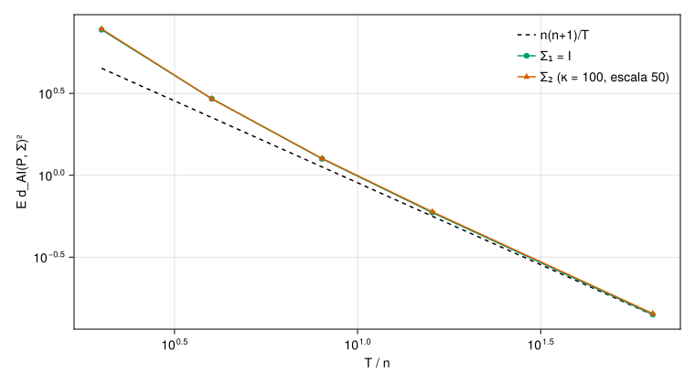

Figura 3.1: Distancia afín-invariante al cuadrado entre la covarianza estimada y la verdadera, frente a $T/n$ (escala logarítmica). Los puntos de $\Sigma_1$ y $\Sigma_2$ coinciden (Teorema 3.1); la recta es la estimación de primer orden $n(n+1)/T$ y queda por debajo cuando $T/n$ es pequeño.

```julia
colores = Makie.wong_colors()
fig = Figure(size = (760, 420))
ax = Axis(fig[1, 1]; xscale = log10, yscale = log10, xlabel = "T / n", ylabel = "E d_AI(P, Σ)²")
x = [1 / f.c for f in filas]
lines!(ax, x, [f.pred for f in filas]; color = :black, linestyle = :dash, label = "n(n+1)/T")
scatterlines!(ax, x, [f.d1 for f in filas]; color = colores[3], label = "Σ₁ = I")
scatterlines!(ax, x, [f.d2 for f in filas]; color = colores[6], marker = :utriangle, label = "Σ₂ (κ = 100, escala 50)")
axislegend(ax; position = :rt, framevisible = false)
fig
```

Tres lecturas:

- **La distancia afín-invariante no depende de $\Sigma$** (Tabla 3.2, Figura 3.1): los valores de $\Sigma_1$ y $\Sigma_2$ coinciden dentro del error estándar, como dice el Teorema 3.1. La euclídea sí depende, y su valor medio concuerda con la fórmula exacta del Teorema 3.2 (Tabla 3.3; las diferencias, de pocos por ciento, son compatibles con el error Monte Carlo): con $\Sigma_2$ es unos seis órdenes de magnitud mayor que con $\Sigma_1$, solo por la escala. Verificado numéricamente
- **El primer orden funciona para $T\gg n$ y falla para $T/n$ pequeño.** Con $T/n\ge16$ el valor medido está cerca de $n(n+1)/T$; con $T/n=2$ es claramente mayor. La razón es que $\Logm W$ amplifica los autovalores pequeños de $W$: al acercarse $T$ a $n$, $\lambda_{\min}\to0$ y $\dAI\to\infty$. Los autovalores extremos de $P$ se dispersan hacia los bordes $(1\mp\sqrt{n/T})^2$ de la ley de Marchenko–Pastur (Tabla 3.4), que describe su comportamiento cuando $n$ y $T$ crecen con $n/T\to c<1$ Citado (Marčenko y Pastur 1967). En $T/n$ pequeño, $\dAI$ **amplifica el ruido del menor autovalor**; es el contrapeso honesto de su invariancia.
- **El suelo de ruido es del orden de $2n(n+1)/T$.** Dos registros con la misma covarianza verdadera ya están a esa distancia. Cualquier diferencia entre grupos o visitas que se quiera detectar debe superarla; es la referencia de los contrastes de permutación del capítulo 6.

## 3.4 Experimento 2: muestras autocorrelacionadas

Las muestras de un EEG de banda no son independientes: las fases de un ritmo se repiten. Entonces $T$ no cuenta las muestras que aportan información. Para saber cuánto vale el número *efectivo*, hace falta un cálculo, no una regla.

**Proposición 3.2 (Suelo de ruido con muestras autocorrelacionadas)** Sean $x^{(1)},\dots,x^{(n)}$ procesos gaussianos estacionarios de media cero, independientes entre sí, con varianza $1$ y autocorrelación común $\rho(k)$, y $P=\tfrac1T\sum_tx_tx_t^\top$ con $x_t=(x^{(1)}_t,\dots,x^{(n)}_t)$. Entonces
$$\mathbb E\,\|P-I\|_F^2=\frac{n(n+1)}{T}\,g_T,\qquad g_T=\sum_{|k|<T}\Big(1-\frac{|k|}{T}\Big)\rho(k)^2 .$$
Con muestras independientes, $g_T=1$. Demostrado

*Demostración*. Para dos procesos gaussianos independientes de media cero, por el teorema de Isserlis, $\operatorname{Cov}\big(x^{(i)}_tx^{(j)}_t,\,x^{(i)}_sx^{(j)}_s\big)=\rho(t-s)^2$ si $i\neq j$ y $2\rho(t-s)^2$ si $i=j$. Por tanto $\operatorname{Var}(P_{ij})=\tfrac1{T^2}\sum_{t,s}\rho(t-s)^2=\tfrac1Tg_T$ para $i\neq j$ y el doble para $i=j$. Sumando las entradas, $\mathbb E\|P-I\|_F^2=\tfrac{g_T}{T}\big(n(n-1)+2n\big)$.

Es decir, el suelo de ruido es el de $T_{\mathrm{ef}}=T/g_T$ muestras independientes. Con un proceso AR(2) con un pico a $10$ Hz muestreado a $100$ Hz ($r=0{,}9$), se calcula $g_T$ y se compara con el error medido, también el de $\dAI$:

**Código**

```julia
function experimento_ar2(; n = 4, R = 400, Ts = (100, 200, 400, 800, 1600))
    rng = StableRNG(20261110)
    r, θ = 0.9, 2π * 10 / 100
    φ1, φ2 = 2r * cos(θ), -r^2
    K = 2 * maximum(Ts)
    ρ = zeros(K); ρ[1] = 1; ρ[2] = φ1 / (1 - φ2)
    for k in 3:K; ρ[k] = φ1 * ρ[k-1] + φ2 * ρ[k-2]; end
    γ0 = 1 / (1 - φ1 * ρ[2] - φ2 * ρ[3])                       # varianza con innovación unitaria
    gT(T) = 1 + 2 * sum((1 - k / T) * ρ[k+1]^2 for k in 1:T-1)
    function ar2(T)                                               # un canal, normalizado a varianza 1
        x = zeros(T + 500)
        for t in 3:T+500; x[t] = φ1 * x[t-1] + φ2 * x[t-2] + randn(rng); end
        return x[501:end] ./ sqrt(γ0)
    end
    res = map(Ts) do T
        v = Float64[]; d = Float64[]
        for _ in 1:R
            X = reduce(hcat, [ar2(T) for _ in 1:n])'              # n × T
            P = Symmetric(X * X' / T)
            push!(v, norm(P - I)^2); push!(d, dAI(P, Matrix(1.0I, n, n))^2)
        end
        (; T, g = gT(T), pred = n * (n + 1) * gT(T) / T, iid = n * (n + 1) / T, v = mean(v), eev = ee(v), d = mean(d), eed = ee(d))
    end
    return res, n
end
res_ar2, n_ar2 = experimento_ar2()
println("| \$T\$ | \$g_T\$ | \$T_{\\mathrm{ef}}=T/g_T\$ | \$n(n+1)/T\$ (independientes) | \$n(n+1)g_T/T\$ | \$\\mathbb E\\|P-I\\|^2\$ (MC) | \$\\mathbb E\\,d_{AI}^2(P,I)\$ (MC) |\n|---|---|---|---|---|---|---|")
for f in res_ar2
    println("| ", f.T, " | ", f3(f.g), " | ", round(Int, f.T / f.g), " | ", f3(f.iid), " | ", f3(f.pred), " | ", f3(f.v), " ± ", f3(f.eev), " | ", f3(f.d), " ± ", f3(f.eed), " |")
end
println("\n: Suelo de ruido con $(n_ar2) canales AR(2) independientes (pico a 10 Hz, \$r=0{,}9\$, 100 Hz de muestreo, 400 réplicas). {#tbl-ar2}")
nothing
```

Tabla 3.5: Suelo de ruido con 4 canales AR(2) independientes (pico a 10 Hz, $r=0{,}9$, 100 Hz de muestreo, 400 réplicas).

| $T$ | $g_T$ | $T_{\mathrm{ef}}=T/g_T$ | $n(n+1)/T$ (independientes) | $n(n+1)g_T/T$ | $\mathbb E\\|P-I\\|^2$ (MC) | $\mathbb E\,d_{AI}^2(P,I)$ (MC) |
| --- | --- | --- | --- | --- | --- | --- |
| 100 | 4.98 | 20 | 0.2 | 0.996 | 0.983 ± 0.0303 | 1.08 ± 0.0241 |
| 200 | 5.09 | 39 | 0.1 | 0.509 | 0.499 ± 0.014 | 0.527 ± 0.0121 |
| 400 | 5.15 | 78 | 0.05 | 0.257 | 0.241 ± 0.00643 | 0.245 ± 0.00551 |
| 800 | 5.17 | 155 | 0.025 | 0.129 | 0.126 ± 0.0029 | 0.129 ± 0.00271 |
| 1600 | 5.19 | 308 | 0.0125 | 0.0648 | 0.0681 ± 0.00168 | 0.0679 ± 0.00157 |

La Tabla 3.5 confirma la proposición: el error euclídeo medido coincide con $n(n+1)g_T/T$ salvo diferencias de unos dos errores estándar, y el de $\dAI$ lo sigue de cerca cuando $T$ es grande Verificado numéricamente. Para este proceso $g_T\approx5$: una época de $T=400$ muestras (4 s a 100 Hz) se comporta como unas $80$ muestras independientes, y su suelo de ruido es unas cinco veces mayor que el que se pronosticaría contando muestras. Para otro proceso hay que recalcular $g_T$ Hipótesis sintética; no existe un factor universal.

## 3.5 La contracción y la invariancia

Con $T/n$ pequeño, una forma habitual de estabilizar $P$ es **contraerla** hacia un objetivo bien condicionado: $P_\lambda=(1-\lambda)P+\lambda\,\dfrac{\tr P}{n}\,I$, con $\lambda\in[0,1]$. Existen reglas para elegir $\lambda$ a partir de los datos Citado (Ledoit y Wolf 2004), pero el punto aquí es otro: el objetivo $\tfrac{\tr P}{n}I$ **no es invariante** por las transformaciones que $\dAI$ sí respeta.

**Proposición 3.3 (La contracción no conmuta con las ganancias)** La contracción conmuta con las similitudes ortogonales y con la escala común, $P_\lambda(QPQ^\top)=QP_\lambda(P)Q^\top$ y $P_\lambda(cP)=cP_\lambda(P)$, pero en general no con una congruencia $P\mapsto DPD$ con $D$ diagonal. Demostrado

*Demostración*. $\tr(QPQ^\top)=\tr P$ y $\tr(cP)=c\tr P$ dan las dos primeras identidades. Contraejemplo para la tercera: $P=\diag(1,4)$, $\lambda=\tfrac12$ y $D=\diag(1,2)$. Entonces $P_\lambda=\diag(1{,}75;\,3{,}25)$ y $DP_\lambda D=\diag(1{,}75;\,13)$, mientras que $DPD=\diag(1,16)$ da $P_\lambda(DPD)=\diag(4{,}75;\,12{,}25)\neq DP_\lambda D$.

Consecuencia: aunque $\dAI$ sea invariante por congruencia, **la distancia entre dos covarianzas contraídas ya no lo es**. Y la contracción tiene un coste de sesgo cuando $\Sigma$ no es esférica:

**Código**

```julia
contraer(P, λ) = symmetrize((1 - λ) * P + λ * (tr(P) / size(P, 1)) * I)
function experimento_contraccion(; n = 8, T = 16, R = 400, λs = (0.0, 0.1, 0.3, 0.6))
    rng = StableRNG(20261111)
    Σ1 = Matrix(1.0I, n, n); Σ2 = spd_kappa(rng, n, 100)
    errores = map(λs) do λ
        (; λ, e1 = mean(dAI(contraer(muestra(rng, Σ1, T), λ), Σ1)^2 for _ in 1:R),
           e2 = mean(dAI(contraer(muestra(rng, Σ2, T), λ), Σ2)^2 for _ in 1:R))
    end
    # invariancia: dos covarianzas, con y sin contracción, antes y después de ganancias comunes D
    A, B = spd_kappa(rng, 6, 20), spd_kappa(rng, 6, 20); D = Diagonal(exp.(0.7 .* randn(rng, 6)))
    cg(M) = symmetrize(D * M * D)
    invar = (sin = (dAI(A, B), dAI(cg(A), cg(B))), con = (dAI(contraer(A, 0.3), contraer(B, 0.3)), dAI(contraer(cg(A), 0.3), contraer(cg(B), 0.3))))
    return errores, invar
end
errores, invar = experimento_contraccion()
println("| \$\\lambda\$ | \$\\mathbb E\\,d_{AI}^2(P_\\lambda,\\Sigma)\$, \$\\Sigma=I\$ | \$\\mathbb E\\,d_{AI}^2(P_\\lambda,\\Sigma)\$, \$\\Sigma\\ne I\$ (\$\\kappa=100\$) |\n|---|---|---|")
for e in errores
    println("| ", e.λ, " | ", f3(e.e1), " | ", f3(e.e2), " |")
end
println("\n: Error de la covarianza contraída con \$n=8\$ y \$T=16\$ (400 réplicas). {#tbl-contraccion}\n")
println("Distancia entre dos covarianzas \$A,B\$ y entre \$DAD,DBD\$ con ganancias comunes \$D\$: sin contracción \$$(f3(invar.sin[1]))\$ y \$$(f3(invar.sin[2]))\$; con contracción \$\\lambda=0{,}3\$ \$$(f3(invar.con[1]))\$ y \$$(f3(invar.con[2]))\$.")
nothing
```

Tabla 3.6: Error de la covarianza contraída con $n=8$ y $T=16$ (400 réplicas).

| $\lambda$ | $\mathbb E\,d_{AI}^2(P_\lambda,\Sigma)$, $\Sigma=I$ | $\mathbb E\,d_{AI}^2(P_\lambda,\Sigma)$, $\Sigma\ne I$ ($\kappa=100$) |
| --- | --- | --- |
| 0.0 | 7.9 | 7.6 |
| 0.1 | 4.93 | 4.91 |
| 0.3 | 2.38 | 9.66 |
| 0.6 | 0.775 | 16.5 |

Distancia entre dos covarianzas $A,B$ y entre $DAD,DBD$ con ganancias comunes $D$: sin contracción $4.11$ y $4.11$; con contracción $\lambda=0{,}3$ $2.47$ y $1.97$.

La Tabla 3.6 muestra el equilibrio: con $\Sigma=I$ (el objetivo es exacto) cuanto más contracción, menor error; con $\Sigma$ anisótropa, contraer un poco ayuda y contraer mucho empeora, porque se sesga hacia una matriz esférica. Y en el último párrafo de salida, sin contracción las dos distancias coinciden y con contracción no Verificado numéricamente. La elección de $\lambda$ es, pues, una decisión de análisis que debe fijarse **antes** de comparar grupos, no una constante de limpieza.

## 3.6 Cuando la matriz sale del cono: rango

El capítulo 2 demostró que la referencia promedio da $HPH$ de rango $n-1$ (Proposición 2.4). Allí $\dAI$ no está definida. Pero la información no se ha perdido: está en un subespacio de dimensión $n-1$, y trabajando en él hay una salida sin ambigüedad.

**Teorema 3.3 (Reducción a $n-1$ canales independiente de la base)** Sean $A,B\in\SPD_n$, $H=I-\tfrac1n\mathbf 1\mathbf 1^\top$ y $Q,Q'\in\R^{(n-1)\times n}$ matrices que restringidas a $\mathbf 1^\perp$ son inyectivas (por ejemplo, eliminar un canal). Entonces $Q(HAH)Q^\top$ y $Q(HBH)Q^\top$ son SPD y
$$\dAI\big(Q(HAH)Q^\top,\,Q(HBH)Q^\top\big)=\dAI\big(Q'(HAH)Q'^\top,\,Q'(HBH)Q'^\top\big).$$
Demostrado

*Demostración*. Sea $V=\mathbf 1^\perp$, de dimensión $n-1$. $HAH$ es definida positiva sobre $V$ y su núcleo es $\mathbf 1$; como $Q|_V$ es un isomorfismo $V\to\R^{n-1}$, $Q(HAH)Q^\top$ es SPD (la demostración es la de la Proposición 3.1, aplicada al subespacio $V$). Sea $R=Q'|_V\,(Q|_V)^{-1}\in\GL(n-1)$. Como $Hx\in V$ para todo $x$, $Q'(HAH)Q'^\top=R\,\big(Q(HAH)Q^\top\big)R^\top$, y lo mismo con $B$. La igualdad de distancias es la Proposición 4.6 con $W=R$.

Con otras métricas, la distancia **sí depende** de qué canal se elimine. Lo comprobamos eliminando cada uno de los seis canales:

**Código**

```julia
function experimento_reduccion(; n = 6)
    rng = StableRNG(20261112)
    A, B = spd_kappa(rng, n, 20), spd_kappa(rng, n, 20)
    H = I - ones(n, n) / n
    HA, HB = H * A * H, H * B * H
    reducir(M, i) = symmetrize(M[setdiff(1:n, i), setdiff(1:n, i)])
    return [(; E = norm(reducir(HA, i) - reducir(HB, i)),
             LE = distance(LogEuclidean(), reducir(HA, i), reducir(HB, i)),
             AI = dAI(reducir(HA, i), reducir(HB, i))) for i in 1:n]
end
reduc = experimento_reduccion()
println("| Geometría | Mínimo | Máximo | Diferencia relativa |\n|---|---|---|---|")
for (nombre, k) in (("Euclídea", :E), ("Log-euclídea", :LE), ("Afín-invariante", :AI))
    v = getfield.(reduc, k)
    println("| ", nombre, " | ", f3(minimum(v)), " | ", f3(maximum(v)), " | ", f3((maximum(v) - minimum(v)) / maximum(v)), " |")
end
println("\n: Distancia entre dos covarianzas con referencia promedio tras eliminar cada uno de los seis canales. {#tbl-reduccion}")
nothing
```

Tabla 3.7: Distancia entre dos covarianzas con referencia promedio tras eliminar cada uno de los seis canales.

| Geometría | Mínimo | Máximo | Diferencia relativa |
| --- | --- | --- | --- |
| Euclídea | 14.1 | 22.7 | 0.377 |
| Log-euclídea | 2.89 | 3.18 | 0.089 |
| Afín-invariante | 3.24 | 3.24 | 2.06e-15 |

Solo $\dAI$ da el mismo valor para cualquier canal eliminado (Tabla 3.7) Verificado numéricamente. Tiene una condición que conviene no olvidar: la reducción compara matrices que comparten el **mismo** núcleo ($\mathbf 1$ en la referencia promedio). Si se eliminan componentes de ICA, el subespacio que queda es distinto en cada persona, y comparar directamente las covarianzas reducidas no tiene el mismo respaldo.

## 3.7 Lo que esto no demuestra

- **No demuestra que $\dAI$ sea mejor que la euclídea.** Demuestra que su ruido de estimación no depende de $\Sigma$ y que la euclídea sí depende; con $T/n$ pequeño, $\dAI$ amplifica el ruido del menor autovalor, y la comparación de potencia entre métricas es del capítulo 6.
- **El suelo de ruido es de primer orden.** Las fórmulas de la ecuación 3.2 valen para $T\gg n$, gaussianas, de media conocida y muestras independientes (Tabla 3.1); fuera de ahí se relajan hipótesis una a una, y el Experimento 1 muestra el fallo con $T/n=2$.
- **$T_{\mathrm{ef}}=T/g_T$ se ha comprobado solo para canales independientes con el mismo AR(2).** Con canales correlacionados, otras bandas o no gaussianidad hay que recalcularlo; las muestras reales del EEG no son un AR(2).
- **Las conclusiones valen para el modelo gaussiano declarado.** El EEG real tiene colas más pesadas y no estacionariedad, que no se han modelado Hipótesis sintética.
- **La contracción mostrada es la más simple** (objetivo esférico). La regla de Ledoit–Wolf para elegir $\lambda$ no se reproduce aquí, y el resultado del Proposición 3.3 no depende de cómo se elija $\lambda$.
- **La reducción a $n-1$ canales exige un núcleo común.** No cubre la ICA con subespacios distintos por persona.

## 3.8 Autoevaluación

**TipDos registros de la misma persona**

Dos registros con exactamente la misma covarianza verdadera, calculados con $T$ muestras cada uno, ¿a qué distancia afín-invariante están, aproximadamente?

**Respuesta.** A unos $\sqrt{2n(n+1)/T}$ (el suelo de ruido de la ecuación 3.2), no a cero. Si se interpreta una distancia sin esa referencia, el ruido parece diferencia real.

**TipCambiar de unidades**

Se expresa $\Sigma$ en mV² en lugar de µV². ¿Cambia el error esperado de la distancia afín-invariante? ¿Y el de la euclídea?

**Respuesta.** El de la afín-invariante no cambia (Teorema 3.1: no depende de $\Sigma$). El de la euclídea cambia con la escala (Teorema 3.2). Es un caso de invariancia por escala común, que recordarás del capítulo 4.

**TipÉpocas con ritmo marcado**

Una época de 4 s a 100 Hz contiene $T=400$ muestras de un ritmo alfa estrecho. ¿Cuenta como 400 muestras independientes?

**Respuesta.** No: la autocorrelación reduce el número efectivo a $T/g_T$, con $g_T$ que depende del proceso (unas cinco veces menos en el ejemplo AR(2), Proposición 3.2). Contar muestras subestima el ruido de estimación.

## 3.9 Ejercicios

**Ejercicio 3.1** Demuestra que $\operatorname{Var}(P_{ij})=\tfrac1T\big(\Sigma_{ii}\Sigma_{jj}+\Sigma_{ij}^2\big)$ para la covarianza muestral de $T$ vectores $N(0,\Sigma)$ independientes, y comprueba con $\Sigma=I$ que $\mathbb E\|P-I\|_F^2=n(n+1)/T$.

**TipPista**

Teorema de Isserlis: $\mathbb E[abcd]=\mathbb E[ab]\mathbb E[cd]+\mathbb E[ac]\mathbb E[bd]+\mathbb E[ad]\mathbb E[bc]$ para gaussianas centradas.

**Ejercicio 3.2** Para un proceso AR(1), $\rho(k)=\phi^{|k|}$, calcula el límite de $g_T$ cuando $T\to\infty$ y deduce $T_{\mathrm{ef}}$. ¿Para qué $\phi$ vale $g=5$?

**NotaSolución**

$g_\infty=\sum_{k\in\mathbb Z}\phi^{2|k|}=\dfrac{1+\phi^2}{1-\phi^2}$, de modo que $T_{\mathrm{ef}}=T\dfrac{1-\phi^2}{1+\phi^2}$. Igualar $g=5$ da $\phi^2=\tfrac23$, es decir, $\phi\approx0{,}82$.

**Ejercicio 3.3** Con la función `muestra` del laboratorio, estima $\mathbb E\,\lambda_{\min}(P)$ para $n=8$ y $T/n\in\{1{,}5;\,2;\,4;\,16\}$ y compárala con $(1-\sqrt{n/T})^2$. ¿Qué ocurre con $\mathbb E\,\dAI(P,I)^2$ cuando $T/n$ se acerca a $1$?

**Ejercicio 3.4** (Laboratorio) Con `contraer` y `dAI` del laboratorio, busca dos matrices $A,B\in\SPD_2$ y unas ganancias $D=\diag(d_1,d_2)$ para las que $\dAI(P_\lambda(A),P_\lambda(B))$ y $\dAI(P_\lambda(DAD),P_\lambda(DBD))$ difieran en más de un $10\,\%$ con $\lambda=0{,}3$.

**Ejercicio 3.5** (Laboratorio) Repite el experimento de reducción sin eliminar ningún canal: proyecta sobre una base ortonormal cualquiera de $\mathbf 1^\perp$ (obtenida, por ejemplo, de la descomposición QR de $H$). Comprueba numéricamente que $\dAI$ coincide con el de la Tabla 3.7 y que las otras dos distancias cambian.

Ledoit, Olivier, y Michael Wolf. 2004. «A well-conditioned estimator for large-dimensional covariance matrices». *Journal of Multivariate Analysis* 88 (2): 365-411. https://doi.org/10.1016/S0047-259X(03)00096-4.

Marčenko, V. A., y L. A. Pastur. 1967. «Distribution of eigenvalues for some sets of random matrices». *Mathematics of the USSR-Sbornik* 1 (4): 457-83. https://doi.org/10.1070/SM1967v001n04ABEH001994.